# Quiz2

Anna Alexandra Grigoryan

4/24/2019

## Introduction

In this project we will be classifing movie reviews as positive or negative using the text of the review. This is binary classification on the IMDB dataset that contains the text of 50,000 movie reviews from the Internet Movie Database. Those are split into 25,000 reviews for training and 25,000 reviews for testing. The training and testing sets are balanced, such that they contain an equal number of positive and negative reviews.

Loading Keras, as well as a few other required libraries.

```r
library(keras)
library(dplyr)
```

```r
library(ggplot2)
library(purrr)
```

The IMDB dataset comes packaged with Keras. It has already been preprocessed such that the reviews are converted to sequences of integers, where each integer represents a specific word in a dictionary.

All we need is downloading the IMDB dataset and splitting it into train and test.

```r
imdb <- dataset_imdb(num_words = 10000)

c(train_data, train_labels) %<-% imdb$train
c(test_data, test_labels) %<-% imdb$test
```

The index mapping words to integers has to be downloaded separately:

```r
word_index <- dataset_imdb_word_index()
```

## Exploration

The dataset comes preprocessed: each example being an array of integers representing the words of the movie review. Each label is an integer value of either 0 or 1, where 0 is a negative review, and 1 is a positive review.

```r
paste0("Training entries: ", length(train_data), ", labels: ", length(train_labels))
```

```
## [1] "Training entries: 25000, labels: 25000"
```

Here’s what the first review looks like:

```r
train_data[[1]]
```

```
##   [1]    1   14   22   16   43  530  973 1622 1385   65  458 4468   66 3941
##  [15]    4  173   36  256    5   25  100   43  838  112   50  670    2    9
##  [29]   35  480  284    5  150    4  172  112  167    2  336  385   39    4
##  [43]  172 4536 1111   17  546   38   13  447    4  192   50   16    6  147
##  [57] 2025   19   14   22    4 1920 4613  469    4   22   71   87   12   16
##  [71]   43  530   38   76   15   13 1247    4   22   17  515   17   12   16
##  [85]  626   18    2    5   62  386   12    8  316    8  106    5    4 2223
##  [99] 5244   16  480   66 3785   33    4  130   12   16   38  619    5   25
## [113]  124   51   36  135   48   25 1415   33    6   22   12  215   28   77
## [127]   52    5   14  407   16   82    2    8    4  107  117 5952   15  256
## [141]    4    2    7 3766    5  723   36   71   43  530  476   26  400  317
## [155]   46    7    4    2 1029   13  104   88    4  381   15  297   98   32
## [169] 2071   56   26  141    6  194 7486   18    4  226   22   21  134  476
## [183]   26  480    5  144   30 5535   18   51   36   28  224   92   25  104
## [197]    4  226   65   16   38 1334   88   12   16  283    5   16 4472  113
## [211]  103   32   15   16 5345   19  178   32
```

Movie reviews have different lengths.Since inputs to a neural network must be the same length, we’ll need to resolve this later.

```r
length(train_data[[1]])
```

```
## [1] 218
```

```r
length(train_data[[2]])
```

```
## [1] 189
```

To convert integers back to text, we create a data frame from it the labels and indexes, and use it in both directions.

```r
word_index_df <- data.frame(
  word = names(word_index),
  idx = unlist(word_index, use.names = FALSE),
  stringsAsFactors = FALSE
)

# The first indices are reserved
word_index_df <- word_index_df %>% mutate(idx = idx + 3)
word_index_df <- word_index_df %>%
  add_row(word = "<PAD>", idx = 0)%>%
  add_row(word = "<START>", idx = 1)%>%
  add_row(word = "<UNK>", idx = 2)%>%
  add_row(word = "<UNUSED>", idx = 3)

word_index_df <- word_index_df %>% arrange(idx)

decode_review <- function(text){
  paste(map(text, function(number) word_index_df %>%
              filter(idx == number) %>%
              select(word) %>%
              pull()),
        collapse = " ")
}
```

Now if we want to decode, we can do the following:

```r
decode_review(train_data[[1]])
```

```
## [1] "<START> this film was just brilliant casting location scenery story direction everyone's really suited the part they played and you could just imagine being there robert <UNK> is an amazing actor and now the same being director <UNK> father came from the same scottish island as myself so i l…
```

## Data preparation

The reviews must be converted to tensors before fed into the neural network. We can either convert them into vectors of 0s and 1s, where the sequence [3, 5] would become a 10,000-dimensional vector that is all zeros except for indices 3 and 5, or pad the arrays so they all have the same length. We will use the second approach.

Since the movie reviews must be the same length, we will use the pad_sequences function to standardize the lengths:

```r
train_data <- pad_sequences(
  train_data,
  value = word_index_df %>% filter(word == "<PAD>") %>% select(idx) %>% pull(),
  padding = "post",
  maxlen = 256
)

test_data <- pad_sequences(
  test_data,
  value = word_index_df %>% filter(word == "<PAD>") %>% select(idx) %>% pull(),
  padding = "post",
  maxlen = 256
)
```

If we check the lengths, we will see that they are equal:

```r
length(train_data[1, ])
```

```
## [1] 256
```

```r
length(train_data[2, ])
```

```
## [1] 256
```

## Model building

The neural network is created by stacking layers, so we need to decide on the number of layers and the hidden units in that layers. layers to use in the model? The input data consists of an array of word-indices. The labels to predict are either 0 or 1.

```r
vocab_size <- 10000

model <- keras_model_sequential()
model %>%
  layer_embedding(input_dim = vocab_size, output_dim = 16) %>%
  layer_global_average_pooling_1d() %>%
  layer_dense(units = 16, activation = "relu") %>%
  layer_dense(units = 1, activation = "sigmoid")

model %>% summary()
```

```
## ___________________________________________________________________________
## Layer (type)                     Output Shape                  Param #
## ===========================================================================
## embedding_1 (Embedding)          (None, None, 16)              160000
## ___________________________________________________________________________
## global_average_pooling1d_1 (Glob (None, 16)                    0
## ___________________________________________________________________________
## dense_1 (Dense)                  (None, 16)                    272
## ___________________________________________________________________________
## dense_2 (Dense)                  (None, 1)                     17
## ===========================================================================
## Total params: 160,289
## Trainable params: 160,289
## Non-trainable params: 0
## ___________________________________________________________________________
```

Embedding layer takes the integer-encoded vocabulary and looks up the embedding vector for each word-index. Global_average_pooling_1d layer returns a fixed-length output vector for each example by averaging over the sequence dimension. This allows the model to handle input of variable length, in the simplest way possible. The last layer is densely connected with a single output node. Using the sigmoid activation function, this value is a float between 0 and 1, representing a probability, or confidence level.

## Compilation

```r
model %>% compile(
  optimizer = 'adam',
  loss = 'binary_crossentropy',
  metrics = list('accuracy')
)
```

## Training

We create validation set by setting apart 10,000 examples from the original training data.

```r
x_val <- train_data[1:10000, ]
partial_x_train <- train_data[10001:nrow(train_data), ]

y_val <- train_labels[1:10000]
partial_y_train <- train_labels[10001:length(train_labels)]
```

```r
early_stopping <- callback_early_stopping(monitor = 'val_loss', patience = 3)

history <- model %>% fit(
  partial_x_train,
  partial_y_train,
  epochs = 100,
  batch_size = 256,
 validation_data = list(x_val, y_val),
  callbacks = early_stopping,
  verbose=1

)
```

## Evaluation

Two values are returned for evaluation. Loss (a number which represents our error, lower values are better), and accuracy(the higher the better)

```r
results <- model %>% evaluate(test_data, test_labels)
results
```

```
## $loss
## [1] 0.3038451
##
## $acc
## [1] 0.87708
```

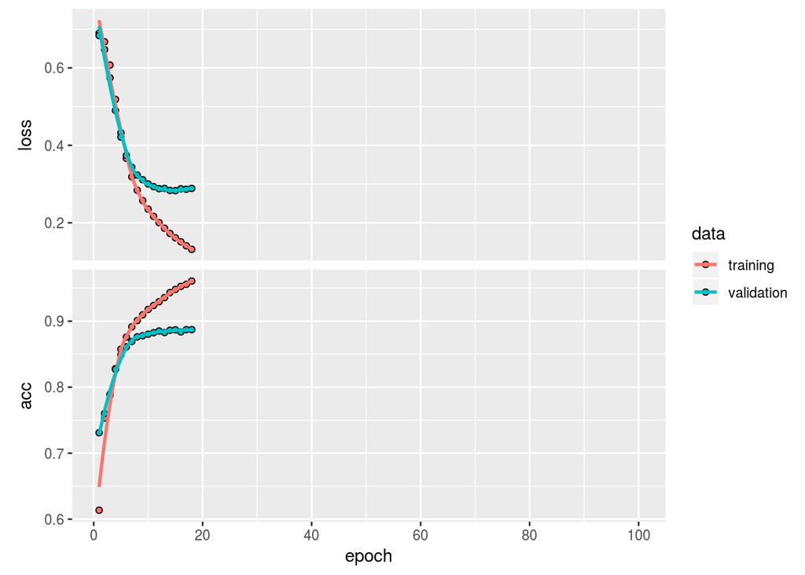

```r
plot(history)
```